# Summarizing

Jae Yeon Kim

04 February, 2022

# 1 Setup

```r
pacman::p_load(tidyverse, gapminder, broom, infer)
```

# 2 Modeling (broom)

## 2.1 Nesting

### 2.1.1 nest

The following example comes from [R for Data Science](https://r4ds.had.co.nz/many-models.html) by Garrett Grolemund and Hadley Wickham.

- How can you run multiple models simultaneously? Using a nested data frame.

[video not shown]

Hadley Wickham: Managing many models with R

- **Grouped data: each row = an observation**
- **Nested data: each row = a group**

**Challenge**

Why did we use `country` and `continent` for nesting variables in the following example?

```r
nested <- gapminder %>%
  group_by(country, continent) %>%
  nest()

head(nested)
```

| country | continent | data |
| --- | --- | --- |
| Afghanistan | Asia |  |
| Albania | Europe |  |
| Algeria | Africa |  |
| Angola | Africa |  |
| Argentina | Americas |  |
| Australia | Oceania |  |

```r
nested$data %>% pluck(1)
```

| year | lifeExp | pop | gdpPercap |
| --- | --- | --- | --- |
| 1952 | 28.801 | 8425333 | 779.4453 |
| 1957 | 30.332 | 9240934 | 820.8530 |
| 1962 | 31.997 | 10267083 | 853.1007 |
| 1967 | 34.020 | 11537966 | 836.1971 |
| 1972 | 36.088 | 13079460 | 739.9811 |
| 1977 | 38.438 | 14880372 | 786.1134 |
| 1982 | 39.854 | 12881816 | 978.0114 |
| 1987 | 40.822 | 13867957 | 852.3959 |
| 1992 | 41.674 | 16317921 | 649.3414 |
| 1997 | 41.763 | 22227415 | 635.3414 |

[output cut: 2 more lines]

- Custom function

```r
lm_model <- function(df) {
  lm(lifeExp ~ year, data = df)
}
```

- Apply function to the nested data

```r
# Apply m_model to the nested data

nested <- nested %>%
  mutate(models = map(data, lm_model)) # Add the list object as a new column

head(nested)
```

| country | continent | data | models |
| --- | --- | --- | --- |
| Afghanistan | Asia |  |  |
| Albania | Europe |  |  |
| Algeria | Africa |  |  |
| Angola | Africa |  |  |
| Argentina | Americas |  |  |
| Australia | Oceania |  |  |

S3 is part of R’s object-oriented systems. If you need further information, check out [this section](http://adv-r.had.co.nz/S3.html) in Hadley’s Advanced R.

### 2.1.2 unnest

- glance()

`glance()` function from `broom` package inspects the quality of a statistical model.

**Additional tips**

- `broom::glance(model)`: for evaluating model quality and/or complexity
- `broom::tidy(model)`: for extracting each coefficient in the model (the estimates + its variability)
- `broom::augment(model, data)`: for getting extra values (residuals, and influence statistics). A convenient tool if you want to plot fitted values and raw data together.

[figure not shown]

Broom: Converting Statistical Models to Tidy Data Frames by David Robinson

```r
glanced <- nested %>%
  mutate(glance = map(models, broom::glance))

# Pluck the first item on the list
glanced$glance %>% pluck(1)
```

| r.squared | adj.r.squared | sigma | statistic | p.value | df | logLik | AIC | BIC | deviance | df.residual | nobs |
| --- | --- | --- | --- | --- | --- | --- | --- | --- | --- | --- | --- |
| 0.9477123 | 0.9424835 | 1.222788 | 181.2494 | 9.835213e-08 | 1 | -18.34693 | 42.69387 | 44.14859 | 14.9521 | 10 | 12 |

```r
# Pull p.value
glanced$glance %>%
  pluck(1) %>%
  pull(p.value)
```

[output not shown]

```r
glanced %>%
  unnest(glance) %>%
  arrange(r.squared)
```

| country | continent | data | models | r.squared | adj.r.squared | sigma | statistic | p.value | df | logLik | AIC | BIC | deviance | df.residual | nobs |
| --- | --- | --- | --- | --- | --- | --- | --- | --- | --- | --- | --- | --- | --- | --- | --- |
| Rwanda | Africa |  |  | 0.01715964 | -0.081124401 | 6.5582695 | 0.1745923 | 6.848927e-01 | 1 | -38.5020543 | 83.0041086 | 84.458829 | 430.1089854 | 10 | 12 |
| Botswana | Africa |  |  | 0.03402340 | -0.062574259 | 6.1121773 | 0.3522177 | 5.660414e-01 | 1 | -37.6567298 | 81.3134597 | 82.768180 | 373.5871172 | 10 | 12 |
| Zimbabwe | Africa |  |  | 0.05623196 | -0.038144842 | 7.2054307 | 0.5958240 | 4.580290e-01 | 1 | -39.6313531 | 85.2627062 | 86.717426 | 519.1823151 | 10 | 12 |
| Zambia | Africa |  |  | 0.05983644 | -0.034179918 | 4.5287128 | 0.6364471 | 4.435318e-01 | 1 | -34.0585860 | 74.1171720 | 75.571892 | 205.0923944 | 10 | 12 |
| Swaziland | Africa |  |  | 0.06821087 | -0.024968046 | 6.6440913 | 0.7320419 | 4.122530e-01 | 1 | -38.6580683 | 83.3161365 | 84.770856 | 441.4394929 | 10 | 12 |
| Lesotho | Africa |  |  | 0.08485635 | -0.006658011 | 5.9339335 | 0.9272463 | 3.582864e-01 | 1 | -37.3015809 | 80.6031617 | 82.057882 | 352.1156687 | 10 | 12 |
| Cote d'Ivoire | Africa |  |  | 0.28337240 | 0.211709644 | 3.9255904 | 3.9542491 | 7.480350e-02 | 1 | -32.3435343 | 70.6870685 | 72.141788 | 154.1026019 | 10 | 12 |
| South Africa | Africa |  |  | 0.31246865 | 0.243715518 | 4.7443562 | 4.5447914 | 5.883744e-02 | 1 | -34.6168020 | 75.2336040 | 76.688324 | 225.0891578 | 10 | 12 |
| Uganda | Africa |  |  | 0.34215382 | 0.276369202 | 3.1876683 | 5.2011219 | 4.573928e-02 | 1 | -29.8448096 | 65.6896193 | 67.144339 | 101.6122930 | 10 | 12 |
| Congo, Dem. Rep. | Africa |  |  | 0.34820278 | 0.283023054 | 2.4294888 | 5.3421948 | 4.340981e-02 | 1 | -26.5855035 | 59.1710069 | 60.625727 | 59.0241587 | 10 | 12 |

[output cut: 132 more lines]

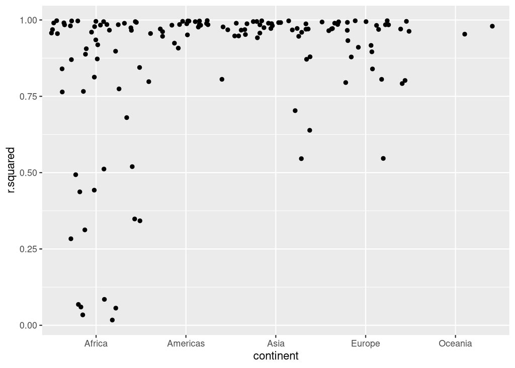

```r
glanced %>%
  unnest(glance) %>%
  ggplot(aes(continent, r.squared)) +
  geom_jitter(width = 0.5)
```

- tidy()

```r
nested <- gapminder %>%
  group_by(continent) %>%
  nest()

nested <- nested %>%
  mutate(models = map(data, ~ lm(lifeExp ~ year + country, data = .)))

tidied <- nested %>%
  mutate(tidied = map(models, broom::tidy))

model_out <- tidied %>%
  unnest(tidied) %>%
  mutate(term = str_replace(term, "country", "")) %>%
  dplyr::select(continent, term, estimate, p.value) %>%
  mutate(p_threshold = ifelse(p.value < 0.05, 1, 0))

model_out %>%
  dplyr::filter(p_threshold == 1) %>%
  pull(term) %>%
  unique()
```

```
##   [1] "(Intercept)"              "year"
##   [3] "Bahrain"                  "Bangladesh"
##   [5] "Cambodia"                 "China"
##   [7] "Hong Kong, China"         "India"
##   [9] "Indonesia"                "Iran"
##  [11] "Iraq"                     "Israel"
##  [13] "Japan"                    "Jordan"
##  [15] "Korea, Dem. Rep."         "Korea, Rep."
##  [17] "Kuwait"                   "Lebanon"
##  [19] "Malaysia"                 "Mongolia"
##  [21] "Myanmar"                  "Nepal"
##  [23] "Oman"                     "Pakistan"
##  [25] "Philippines"              "Saudi Arabia"
##  [27] "Singapore"                "Sri Lanka"
##  [29] "Syria"                    "Taiwan"
```

[output cut: 47 more lines]

```r
model_out %>%
  dplyr::filter(p_threshold == 0) %>%
  pull(term) %>%
  unique()
```

```
##  [1] "Bosnia and Herzegovina" "Bulgaria"               "Hungary"
##  [4] "Romania"                "Serbia"                 "Egypt"
##  [7] "Libya"                  "Morocco"                "Sao Tome and Principe"
## [10] "Tunisia"                "Chile"                  "Costa Rica"
## [13] "Cuba"                   "Jamaica"                "Panama"
## [16] "Uruguay"
```

## 2.2 Mapping

We tasted a bit of how `map()` function works. Let’s dig into it more in-depth, as this family of functions is useful. See Rebecca Barter’s excellent tutorial on the `purrr` package for more information. In her words, this is “the tidyverse’s answer to apply functions for iteration”. `map()` function can take a vector (of any type), a list, and a dataframe for input.

```r
multiply <- function(x) {
  x * x
}

df <- list(
  first_obs = rnorm(7, 1, sd = 1),
  second_obs = rnorm(7, 2, sd = 2)
) # normal distribution
```

**Challenge**

If you want to know more about the power and joy of functional programming in R (e.g., `purrr::map()`), then please take [“How to Automate Repeated Things in R”](https://github.com/dlab-berkeley/R-functional-programming) workshop.

# 3 Hypothesis testing

Statistical inference: does the effect/difference in observed data occur by chance?

Null hypothesis: everything was random Alternative hypothesis: everything was not random. Note that this does not mean that a particular factor influenced the outcome of interest. Statistical inference != Causal inference (causes and effects)

$Y = X_{1} + X_{2} + X_{3} \epsilon$

[`infer`](https://github.com/tidymodels/infer) is for tidyverse-friendly statistical inference.

**Workflow**

1. `specify()` specify a formula
2. `hypothesize()` declare the null hypothesis
3. `generate()` generate data based on the null hypothesis
4. `calculate()` calculate a distribution of statistics from the generated data to form the null distribution

From infer package

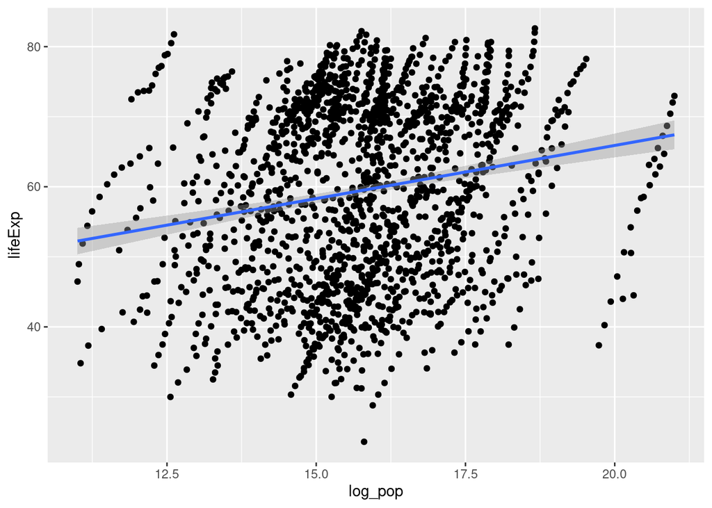

```r
gapminder <- gapminder %>%
  mutate(log_pop = log(pop))

ggplot(aes(x = log_pop, y = lifeExp), data = gapminder) +
  geom_point() +
  geom_smooth(method = "lm")
```

```r
# Calculate the observed statistic: Observed slopes
observed_slopes <- gapminder %>%
  # specify(formula = lifeExp ~ log_pop) %>%
  specify(formula = lifeExp ~ log_pop) %>%
  calculate(stat = "slope")

# Generate the null distribution: Null slopes
null_slopes <- gapminder %>%
  # Specify a formula
  specify(formula = lifeExp ~ log_pop) %>%
  # Hypothesize (point estimation)
  hypothesize(null = "point", mu = 0) %>%
  # Generate sampling distributions (bootstrapping)
  generate(reps = 1000, type = "bootstrap") %>%
  # Calculate statistics
  calculate(stat = "slope")

# Return data
null_slopes %>%
  # p-value is just the probability that observed pattern could arise if the null hypothesis was true
  # In social science convention, if alpha is below 0.005 (note: this is totally arbitrary), then the observed distribution is statistically significant.
  get_p_value(
    obs_stat = observed_slopes,
    direction = "both"
  )
```

| p_value |
| --- |
| 0.998 |

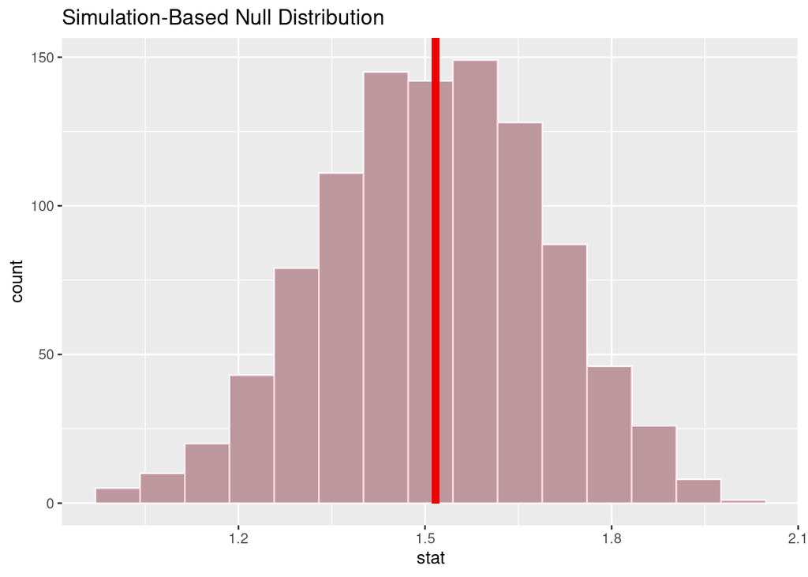

```r
# Visualize output
visualize(null_slopes) +
  shade_p_value(
    obs_stat = observed_slopes,
    direction = "both"
  )
```